## Practicle Machine Learning (Course Project Writeup)

### Goal:

The goal of your project is to predict the Classe Variable in the train dataset and implement the learned algorithm on the test dataset.

### The Approach:

My Approach to the problem is very simple. First we will get rid of the variables having high missing values. After making sure that, now we have variables which do not have any missing values we will look for variables with very high correlation, because these highly correlated varibles can lead to multicollinearity which can increase miss classification error rate. Now as of now we have only 32 Variables that can used for prediction.

The next big quest is choosing the right algorithm which learns from the data to its best. Without much effort and extensively exploring the forums I found out that randomForest will be the best choice for the data, which uses the bragging method that is a high variance, low bias technique.

The learned algorithm from this data is then used to predict the test data.

#### Importing the train and test dataset into the R

```r
file.loc<-"D:\\github\\practicle_machine_learning\\"
setwd(paste0(file.loc,"submission files"))
train<-read.csv(paste0(file.loc,"pml-training.csv"),stringsAsFactor=FALSE,skip = 0,fill=NA,comment.char="#")
test<-read.csv(paste0(file.loc,"pml-testing.csv"))
```

#### Removing Missing data Variables:

The train dataset consist of 160 variables and 19622 observations from which we have to learn.

```r
length(names(train))  # No.. of Varaibles
```

```
## [1] 160
```

```r
nrow(train)           # No. of Observations
```

```
## [1] 19622
```

```r
var<-names(train)[apply(train,2,function(x) table(is.na(x))[1]==19622)]
train2<-train[,var]
test2<-test[,var[-length(var)]]
```

Now, when we see the variables we still have some variables with “” as value. Luckly we have a pattern of missing value within variables. Further we reduced our variables and kept only the numeric variables giving HAR information.

*Note : There is no need of creating the data frame again and again. I have created this only to bring clear picture for my approach.

```r
var2<-melt(apply(train2,2,function(x) sum(ifelse(x=="",1,0)))==0)
select.var<-rownames(var2)[var2$value==TRUE]
train3<-train2[,select.var]
test3<-test2[,select.var[-length(select.var)]]
train4<-train3[,names(train3[-c(1:7,length(train3))])]      # only considering numeric variable from HAR sensor
test4<-test3[,names(test3[-c(1:7)])]
```

Now, we have to look for correlations within numeric variables to remove multicollinearity.

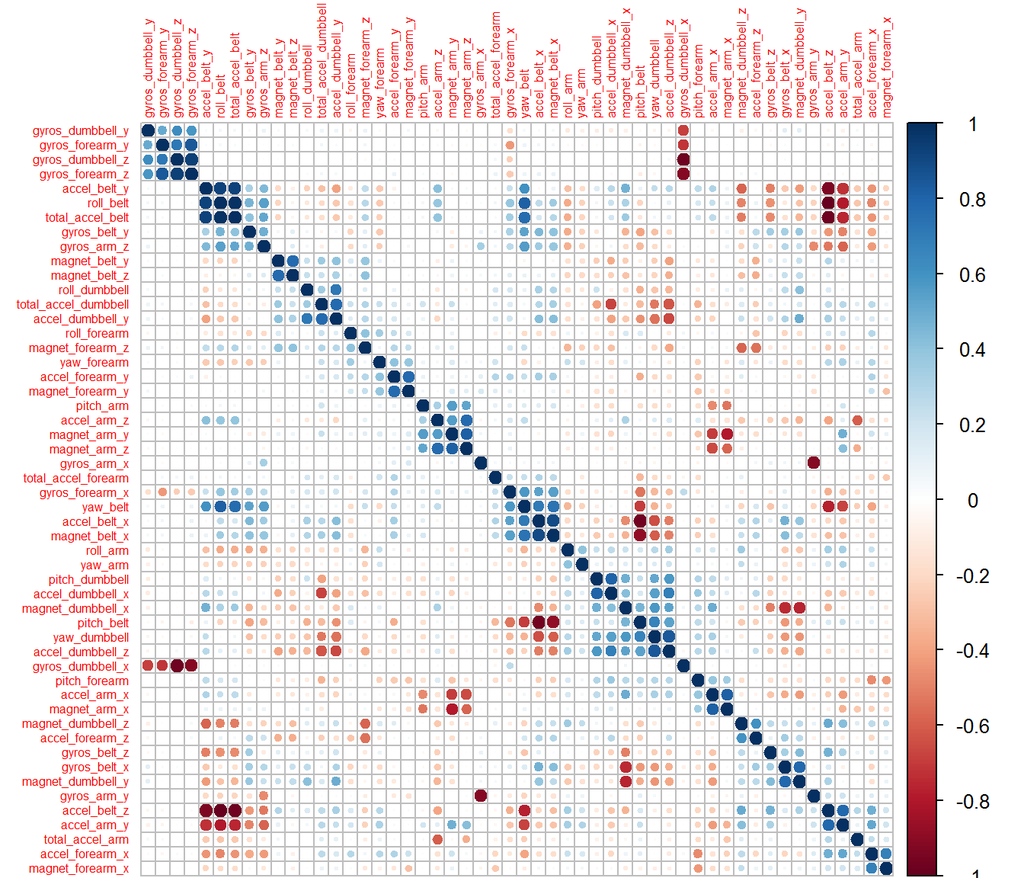

```r
correlations <- cor(train4)                                 # finding correlations
corrplot(correlations,order = "hclust",tl.cex = .5)         # plotting correlation matrix of variables
```

```r
highCorr <- findCorrelation(correlations, cutoff = .75)     # finding variables with high correlation
predictor <- train4[, -highCorr]                            # dataframe of train predictors
filtered.test4 <- test4[, -highCorr]                        # dataframe of test predictors
classe<-train3$classe                                       # target variable
trainData<-cbind(classe,predictor)                          # training dataset ready for prediction
```

Now, we have variables which are good for prediction.

#### Random Forest Algorithm

```r
rfModel <- randomForest(classe ~ .,data = trainData,importance = TRUE,ntrees = 10)
print(rfModel)                                   # Confusion Matrix showing the accuracy
```

```
##
## Call:
##  randomForest(formula = classe ~ ., data = trainData, importance = TRUE,      ntrees = 10)
##                Type of random forest: classification
##                      Number of trees: 500
## No. of variables tried at each split: 5
##
##         OOB estimate of  error rate: 0.42%
## Confusion matrix:
##      A    B    C    D    E class.error
## A 5577    2    0    0    1   0.0005376
## B   10 3781    5    0    1   0.0042139
## C    0   17 3392   13    0   0.0087668
## D    0    0   27 3186    3   0.0093284
## E    0    0    0    4 3603   0.0011090
```

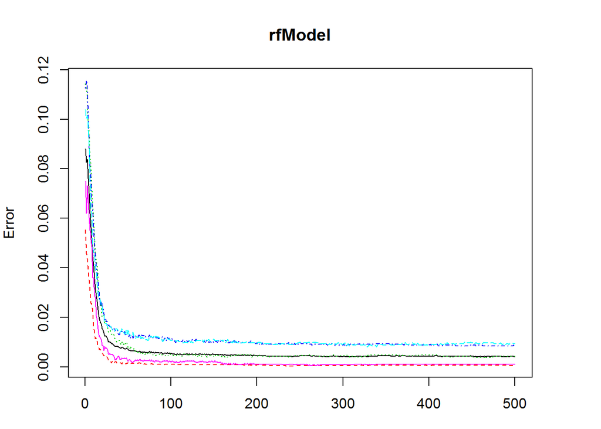

```r
par(mar=c(3,4,4,4))
plot(rfModel)                                    # Error rate plot for each class
```

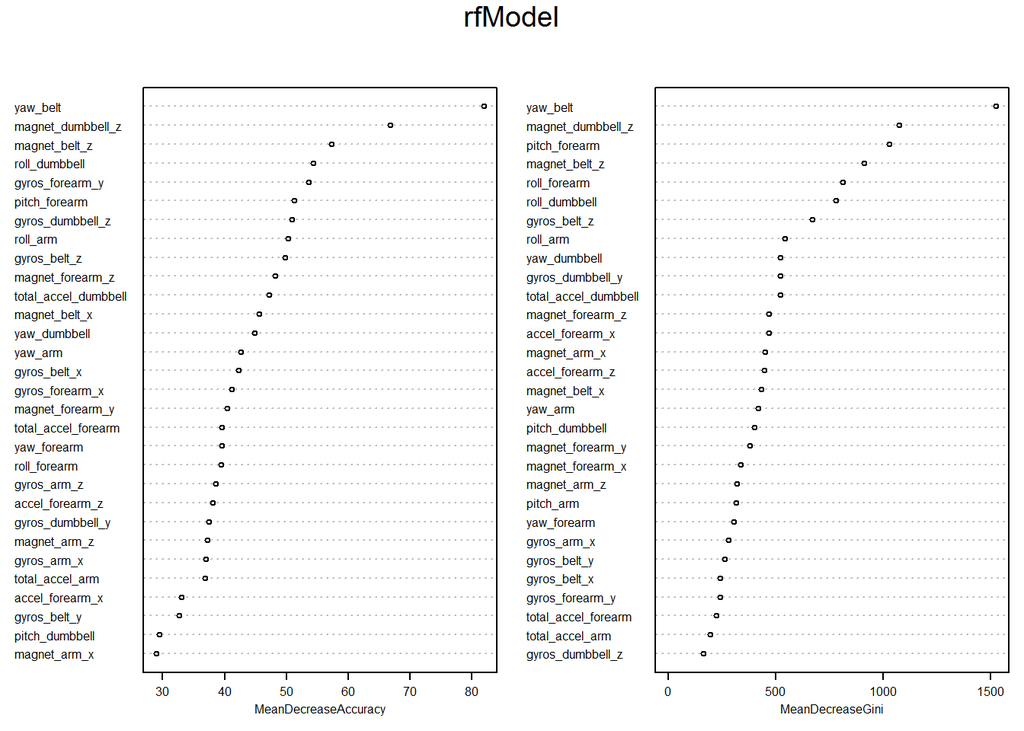

```r
varImpPlot(rfModel,cex=.5)                       # Importance of Variable on Gini Index
```

```r
out.test<-predict(rfModel,filtered.test4)        # predicting the test set
```

#### Saving the output for Course Project: Submission

```r
answers<- as.vector(out.test)

pml_write_files = function(x){
  n = length(x)
  for(i in 1:n){
    filename = paste0("problem_id_",i,".txt")
    write.table(x[i],file=filename,quote=FALSE,row.names=FALSE,col.names=FALSE)
  }
}

pml_write_files(answers)
```